# 1 Building Zoomorphic Creature

This chapter is about defining and creating zoomorphic creatures.

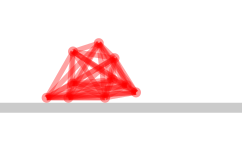

Figure 1: Example of a creature.

Figure 1 gives the example of such a creature. It is make of join points and muscles. Each muscles has two extremities and each extremity is connected a join point. A join point may be host of several extremities.

A muscle is a complex element in our model. Each muscle oscillates and has a strength, which makes it able to resist against external forces. Each muscle oscillate along its internal clock.

A creature is subject to the gravity. Muscles have no weight, but a join point has a weight.

Such a creature, at its inception, does not do much. However, we will make it evolve to solve a particular task. The task we will consider are displacing itself toward a direction and jumping.

The chapter is very long as it lays out the infrastructure to simulate a complex. We will produce creature, that we qualify as *zoomorphic* since they could be (although remotely) considered as a small digital animal.

Note that this long chapter is does not directly related to genetic algorithm. The following chapter will evolve creatures to solve a simple task, such as moving toward a direction or going through some obstacles.

## 1.1 Modeling Join Points

Each element in our simulation has a visual representation. We will therefore define the class `CVisualElement`:

```
Object subclass: #CVisualElement
    instanceVariableNames: 'element'
    classVariableNames: ''
    poolDictionaries: ''
    category: 'Creature'
```

The class `CVisualElement` has a variable `element` which will contains a Roassal visual element. This element will have to be created by subclasses of the our class using the method `createElement`:

```
CVisualElement>>createElement
    "Should be overridden in subclasses. The method should
    initialize the element variable"
    self subclassResponsibility
```

The variable `element` may be accessed using:

```
CVisualElement>>element
    "Return the Roassal element"
    ^ element
```

Join points will be represented as instance of the class `CNode`. We define the class as follows:

```
CVisualElement subclass: #CNode
    instanceVariableNames: 'speedVector force isOnPlatform'
    classVariableNames: ''
    poolDictionaries: ''
    category: 'Creature'
```

A node has three variables: - `force` represents the sum of the external forces. This vector will impact the speed and therefore the movement of the node; - `speedVector` represents the speed of the node. The speed will be affected by friction of the environment; - `isOnPlatform` indicates whether a node is on a platform. Knowing this is relevant because it may affect the speed of the node.

The initialization of a node is defined as follows:

```
CNode>>initialize
    super initialize.
    isOnPlatform := false.
    self resetSpeed.
    self resetForce
```

When created, a node has no speed, it is not on a platform, and has no external force.

The external force may be reset using the method:

```
CNode>>resetForce
    "Reset the force exercising on the node"
    force := 0 @ 0
```

Similarly, the speed is reset using the method:

```
CNode>>resetSpeed
    "Make the node stop by canceling its speed"
    speedVector := 0 @ 0
```

A node is visually represented with a small gray circle. We therefore define the method `createElement`:

```
CNode>>createElement
    element := RTEllipse new size: 10;
                color: Color gray trans; element.
    element @ RTDraggable
```

A node is subject to external forces. We define the method `addForce:` that simply adds a force, expressed as a point, to the forces already exercising on the node. The method is:

```
CNode>>addForce: aForceAsPoint
    "Make the node subject of an external force"
    force := force + aForceAsPoint
```

Overall, our simulation is driven by a beat, which will be globally triggered. The method `beat` is defined as follows:

```
CNode>>beat
    "Make the node act according to the force and speed acting on the node"
    speedVector := speedVector + self gravityForce + force.
    speedVector := speedVector * 0.9.
    isOnPlatform ifTrue: [
        speedVector := speedVector x * 0.3 @ speedVector y ].
    self translateBy: speedVector
```

At each beat, the gravity and the external forces are summed to the speed. We arbitrary set a friction, which is the result of the air in the physical environment.

The gravity is represented by an arbitrary point:

```
CNode>>gravityForce
    "A fixed force representing a gravity"
    ^ 0 @ 0.3
```

Creature will live in a world made of platforms. A platform is an instance of the class `CPlatform`, which we will see later. We define the method `checkForCollision:` as follows:

```
CNode>>checkForCollision: platforms
    "Verify if the node is on a platform. If it is the case,
    the variable isOnPlatform is set to true"
    isOnPlatform := false.
    platforms
        do: [ :p |
            (p touch: self)
                ifTrue: [
                    speedVector := speedVector x @ 0.
                    p adjustNodeIfNecessary: self.
                    isOnPlatform := true.
                    ^ self ] ]
```

First the variable `isOnPlatform` is set to `false`. If the node touches at least one platform, then the Y component of the speed is set to 0 and the variable `isOnPlatform` is set to `true`. Due to some impression of our model, we need to let the platform make some adjustment of the node. In particular, it ensures that a node is not *inside* a platform. We will see this method later, when we will define the class `CPlatform`.

The variable `isOnPlatform` may be accessed using the accessor:

```
CNode>>isOnPlatform
    "Is the node is on a platform?"
    ^ isOnPlatform
```

The position of the node is given by the method `position`. It simply asks to the Roassal `element` its position. A newly created node is at a position `0@0`. The method is defined as follows:

```
CNode>>position
    "Return the position of the node"
    ^ element position
```

A node needs to be translated to reflect the effect of the environment. We define a first method to translate the node by an incremental step using the method:

```
CNode>>translateBy: aPoint
    "Translate the node by an incremental point"
    element translateBy: aPoint.
```

A new position may be set to a node using the method:

```
CNode>>translateTo: aPoint
    "Translate the node to a new position"
    element translateTo: aPoint.
```

## 1.2 Platform

In addition to the gravity that we have described above, the environment may affect the nodes (and therefore the creatures) with platforms. We define the class `CPlatform` as a subclass of `CVisualElement`:

```
CVisualElement subclass: #CPlatform
    instanceVariableNames: 'width height'
    classVariableNames: ''
    poolDictionaries: ''
    category: 'Creature'
```

We initialize a platform with a width of 100 pixels:

```
CPlatform>>initialize
    super initialize.
    self width: 100.
    self height: 10
```

The width of a platform is set using:

```
CPlatform>>width: aWidthAsNumber
    "Set the width of the platform"
    width := aWidthAsNumber
```

The height of a platform is set using:

```
CPlatform>>height: aHeightAsNumber
    "Set the width of the platform"
    height := aHeightAsNumber.
```

The creation of the element is a simple rectangle:

```
CPlatform>>createElement
    element ifNotNil: [ "already created" ^ self ].
    element := RTBox new width: width; height: height; color: Color gray; element.
```

A platform may be translated to a particular position using:

```
CPlatform>>translateTo: aPosition
    "Translate the platform to a particular position"
    self createElement.
    element translateTo: aPosition
```

The primitive to handle effect of the platform is the collision detection. We define the method `touch:`:

```
CPlatform>>touch: node
    "Answer whether the platform touch the node provided as argument"
    ^ node element encompassingRectangle intersects: self element encompassingRectangle
```

The method `touch:` returns `true` or `false` indicating whether the provided `node` is above a platform.

In case that a collision happens, it is important to adjust the position of a node if necessary:

```
CPlatform>>adjustNodeIfNecessary: node
    "Answer whether the platform touch the node"
    | bottomNode topPlatform |
    bottomNode := node element encompassingRectangle bottomCenter y.
    topPlatform := self element encompassingRectangle topCenter y.

    topPlatform < bottomNode
        ifTrue: [ node translateBy: 0 @ (topPlatform - bottomNode) ]
```

Such an adjustment is necessary because the node translation is discrete and not continuous. As a consequence, it may happens that a falling node is within the platform, and should therefore be translated to be on top of it.

## 1.3 Muscle

A muscle, which is at the core of our simulation, is a complex data structure. A muscle is an oscillating edge, having a strength. It connects two join points (*i.e.*, nodes). We will first define the class `CConnection` to represent the connection between two nodes. We define the class `CConnection`:

```
CVisualElement subclass: #CConnection
    instanceVariableNames: 'node1 node2'
    classVariableNames: ''
    poolDictionaries: ''
    category: 'Creature'
```

We define `node1` and `node2` the two extremities represented by instance of `CNode`. The first extremity is obtained using:

```
CConnection>>node1
    ^ node1
```

The first extremity is set using the method:

```
CConnection>>node1: aNode
    node1 := aNode
```

The second extremity is obtained with:

```
CConnection>>node2
    ^ node2
```

It is set using:

```
CConnection>>node2: aNode
    node2 := aNode
```

A muscle has an internal timer that drives the oscillation. We define the class `CMuscle` as follows:

```
CConnection subclass: #CMuscle
    instanceVariableNames: 'time length1 length2 time1 time2 strength color'
    classVariableNames: ''
    poolDictionaries: ''
    category: 'Creature'
```

The class `CMuscle` has the following variables:

- the `strength` represents how much resistance a muscle has when subject to external forces, such as the weights of the connected join points;
- the length of the muscle oscillate between `length1` and `length2`;
- an internal timer, represented with the variable `time`;
- two thresholds used by the internal clock, `time1` and `time2`;
- a `color` variable representing the color of the muscle.

A muscle’s length oscillates along its internal timer. The method `beat` increases the variable `time` by 1.

```
CMuscle>>beat
    "Beating a muscle increases its timer"
    time := time + 1.
    time = self maxTime ifTrue: [ time := 0 ].
```

If the time reaches a maximum time, then it is reset to 0. The internal timer is therefore cyclic. When created, a muscle as 0 as a timer. We define the initialization:

```
CMuscle>>initialize
    super initialize.
    time := 0.
    color := Color red.
```

The visual representation of a muscle is given by the method `createElement`. A muscle is a straight line joining `node1` and `node2`. The method `createElement` is defined as:

```
CMuscle>>createElement
    "A muscle is a transparent line between the two nodes"
    element := RTLine new color: (color alpha: 0.3); width: 5;
                edgeFrom: node1 element to: node2 element
```

The color of a muscle is set by:

```
CMuscle>>color: aColor
    "Set the color of the muscle"
    color := aColor
```

Note that the method `createElement` will make the color translucent. This is useful as many muscles do overlap.

A muscle as a variable length. The actual length of a muscle is either `length1` or `length2`. If the muscle timer is below a lower threshold (*i.e.,* value of `self minTime`), then the muscle length is `length1`, else it is `length2`. We define the method `length` as follows:

```
CMuscle>>length
    "Maybe rename it to ideal length"
    ^ time < self minTime
        ifTrue: [ length1 ]
        ifFalse: [ length2 ]
```

If the `time` variable has a value lower than the lower threshold, then we say we are at the beginning of a cycle. We refer to the end of the muscle cycle if `time` is greater than `self minTime`. We define some accessing methods to the variable `length1` and `length2`:

```
CMuscle>>length1
    "Length of a muscle at the beginning of a cycle"
    ^ length1
```

The value is set using:

```
CMuscle>>length1: aLengthAsInteger
    "Set the muscle length at the beginning of a cycle"
    length1 := aLengthAsInteger
```

Similarly, `length2` is accessed using:

```
CMuscle>>length2
    "Length of a muscle at the end of a cycle"
    ^ length2
```

The second length is set using:

```
CMuscle>>length2: aLengthAsInteger
    length2 := aLengthAsInteger
```

The cycle length is given by the value of `maxTime`, it is defined as the maximum value between `time1` and `time2`:

```
CMuscle>>maxTime
    "Return the cycle length"
    ^ time1 max: time2
```

Similarly, the threshold is given by the method `minTime`:

```
CMuscle>>minTime
    "Return the timer threshold between to switch between length1 and length2"
    ^ time1 min: time2
```

A muscle as a strength, accessible using:

```
CMuscle>>strength
    "Return the strength of the muscle"
    ^ strength
```

The strength of a muscle is used to compute the forces that will be applied to the extremity nodes by the muscle. The strength is set using:

```
CMuscle>>strength: strengthAsFloat
    "Set the strength that is applied to the extremities"
    strength := strengthAsFloat
```

The muscle internal timer is increase at each beat, as defined above. The first timer threshold is set using:

```
CMuscle>>time1: anInteger
    time1 := anInteger
```

The `time1` value is obtained with:

```
CMuscle>>time1
    ^ time1
```

As we will later see, muscle attributes have to be serialized in order to be encoded and decoded from GA individuals. We therefore need to access these values. The second time threshold is set using:

```
CMuscle>>time2: anInteger
    time2 := anInteger
```

It is accessed using:

```
CMuscle>>time2
    ^ time2
```

Each creature will be randomly generated. We will have to monitor how nodes are used by the muscles. We define the method to test whether a muscle connects two nodes:

```
CMuscle>>usesNodes: twoNodes
    "The method accepts an array of two nodes as argument.
    Return true if the muscle connects the two nodes."
    ^ (node1 == twoNodes first and: [ node2 == twoNodes second ]) or: [
        node1 == twoNodes second and: [ node2 == twoNodes first ] ]
```

The definition of a muscle is now complete. Our creature will be randomly generated, which means that muscle will have to be also randomly generated. The next section defines a generator of muscles.

## 1.4 Muscle Generator

When a muscle is randomly generated, attributes defining the muscle (*i.e.,* `time1`, `time2`, `length1`, `length2`, `strength`) have to be also randomly generated. The class `CMuscleGenerator` has the responsibility to generate random muscles. A muscle generator is parameterized with a range for each attribute, expressed with a minimum value and a delta value. We define the class `CMuscleGenerator`:

```
Object subclass: #CMuscleGenerator
    instanceVariableNames: 'random minStrength deltaStrength minLength deltaLength minTime deltaTime'
    classVariableNames: ''
    poolDictionaries: ''
    category: 'Creature'
```

The initialization of a generator assign some values that are convenient in most of the example we will later see:

```
CMuscleGenerator>>initialize
    super initialize.
    self resetSeed.
    minLength := 10.
    deltaLength := 30.
    minTime := 4.
    deltaTime := 200.
    minStrength := 1.
    deltaStrength := 3
```

The random number generator is created using `resetSeed`:

```
CMuscleGenerator>>resetSeed.
    random := Random seed: 42.
```

The delta of a value corresponds to an interval from which values will be randomly picked. The delta length is set using:

```
CMuscleGenerator>>deltaLength: anInteger
    deltaLength := anInteger
```

The delta strength is set using:

```
CMuscleGenerator>>deltaStrength: anInteger
    deltaStrength := anInteger
```

The delta time is set using:

```
CMuscleGenerator>>deltaTime: anInteger
    deltaTime := anInteger
```

The minimum value a length can have is set using:

```
CMuscleGenerator>>minLength: anInteger
    "Set the minimum value a muscle length may have"
    minLength := anInteger
```

Similarly, the minimum strength is set:

```
CMuscleGenerator>>minStrength: anInteger
    "Set the minimum value a muscle strength can have"
    minStrength := anInteger
```

The minimum time threshold is set using:

```
CMuscleGenerator>>minTime: anInteger
    "Set the minimum value a muscle time threshold can be"
    minTime := anInteger
```

A length is generated using a dedicated method:

```
CMuscleGenerator>>generateLength
    "Return a length within the specified range"
    ^ minLength + (random nextInt: deltaLength)
```

Similarly, the strength is generated with:

```
CMuscleGenerator>>generateStrength
    "Return a strength within the specified range"
    ^ random next * deltaStrength + minStrength
```

A time threshold is generated with:

```
CMuscleGenerator>>generateTime
    "Return a time within the specified range"
    ^ (random nextInt: deltaTime) + minTime
```

A central method of the generator is `createMuscleFrom:to:`. This method is used to produce a muscle between two nodes:

```
CMuscleGenerator>>createMuscleFrom: aNode to: anotherNode
    "Return a new muscle connecting two nodes"
    | m |
    m := CMuscle new.
    m node1: aNode.
    m node2: anotherNode.
    m length1: self generateLength.
    m length2: self generateLength.
    m time1: self generateTime.
    m time2: self generateTime.
"   m time2: 200. @@TODO: CHECK THIS"
    m strength: self generateStrength.
    ^ m
```

A central aspect of applying a genetic algorithm to search for optimal muscle configuration require adequately managing the mapping between a set of values and a muscle definition. A muscle can be *serialized* into a set of values, and a set of values can be *materialized* into a muscle. These operations are necessary to produce a creature from a given set individual from our genetic algorithm.

```
CMuscleGenerator>>serializeMuscle: aMuscle
    "Return an array describing the muscle provided as argument"
    ^ Array
        with: aMuscle length1
        with: aMuscle length2
        with: aMuscle strength
        with: aMuscle time1
        with: aMuscle time2
```

The materialization configures a provided muscle with an array of values

```
CMuscleGenerator>>materialize: values inMuscle: aMuscle
    "Configure the provided muscle with some values"
    aMuscle length1: values first.
    aMuscle length2: values second.
    aMuscle strength: values third.
    aMuscle time1: values fourth.
    aMuscle time2: values fifth
```

An individual within our genetic algorithm will contain the attributes of all the muscles involved within a creature. Our algorithm will need a way to produce a particular value for a given gene position in the individual genetic information. The following method address this need:

```
CMuscleGenerator>>valueForIndex: anIndex
    "Produce a value for a given index.
    This method is used to generate a gene in the GA algorithm"
    | i |
    i := (anIndex - 1) % 5.
    i = 0 ifTrue: [ ^ self generateLength ].
    i = 1 ifTrue: [ ^ self generateLength ].
    i = 2 ifTrue: [ ^ self generateStrength ].
    i = 3 ifTrue: [ ^ self generateTime ].
    i = 4 ifTrue: [ ^ self generateTime ].
    self error: 'Should not be here'
```

It is important to note that the three methods `serializeMuscle:`, `materialize:inMuscle:`, and `valueForIndex:`, heavily rely on the order of the attributes.

## 1.5 Creature

We define a creature as an instance of the class `CCreature`, defined as follow:

```
Object subclass: #CCreature
    instanceVariableNames: 'nodes muscles random muscleGenerator color'
    classVariableNames: ''
    poolDictionaries: ''
    category: 'Creature'
```

A creature is essentially made of a set of nodes and a set of muscle. We will run our genetic algorithm on optimizing the configuration of the muscles. So, the initial configuration of our muscle is random, which is why we need a `random` number generator. Muscles are a complex structure which require a dedicated object to be built. As we have seen, the class `CMuscleGenerator` is a convenient way to build muscles.

A creature is initialized as follow:

```
CCreature>>initialize
    super initialize.
    nodes := OrderedCollection new.
    muscles := OrderedCollection new.
    random := Random seed: 42.
    muscleGenerator := CMuscleGenerator new.
    color := Color red.
```

A muscle is red per default. Its colors may be particularized with:

```
CCreature>>color: aColor
    "Set the color of the creature"
    color := aColor
```

Muscle and can be generated and added in a creature using the method:

```
CCreature>>addMuscleFrom: aNode to: anotherNode
    "Generate and add a muscle between two nodes"
    muscles add: (muscleGenerator createMuscleFrom: aNode to: anotherNode)
```

The number of muscles is obtained with:

```
CCreature>>numberOfMuscles
    "Return the number of muscles defining the creature"
    ^ muscles size
```

Each beat produces a beat for each node and each muscle. After, the physic rules have to be applied between the muscles and the nodes. The method `beat` is defined as:

```
CCreature>>beat
    "Execute a unit of behavior"
    nodes do: #beat.
    muscles do: #beat.
    self reachStable
```

Collision between a creature and the platforms is achieved using the method `checkForCollision:`, defined as follows:

```
CCreature>>checkForCollision: platforms
    nodes do: [ :n | n checkForCollision: platforms ].
    self simulateNoise.
```

The physic engine we are implementing is minimal and is far from being complete. We need to add some noise in the way that the physical is simulated. For example, random noise accompanying the physic is not considered so far. However, such a noise is necessary to avoid singular situations, for example if all the nodes are exactly at the vertical level. We simply add some noise by moving a node randomly:

```
CCreature>>simulateNoise
    "Produce noise in our simulation"
    | direction |
    direction := ((random nextInt: 3) - 2) @ ((random nextInt: 3) - 2).
    (nodes atRandom: random) translateBy: direction
```

All the necessary to model creature is now in place. The next section focuses on the creation of creature.

## 1.6 Creating Creature

Even if we will produce creatures with simple shapes, manually creating creature is tedious. We define some dedicated methods. Adding nodes to a creature is achieved with the method `configureNodes:`:

```
CCreature>>configureNodes: nbNodes
    "Add a number of nodes in our creature"
    nbNodes timesRepeat: [ nodes add: CNode new createElement ]
```

A ball-like shape is created using:

```
CCreature>>configureBall: numberOfNodes
    "Produce a ball-like creature"
    | existingMuscles |
    muscleGenerator := CMuscleGenerator new
        minStrength: 0.01;
        deltaStrength: 0.5;
        minLength: 10;
        deltaLength: 80;
        deltaTime: 200;
        minTime: 20.

    "Add some nodes nodes"
    self configureNodes: numberOfNodes.

    "Connect each node with all the other nodes"
    existingMuscles := OrderedCollection new.
    nodes do: [ :n1 |
        (nodes copyWithout: n1) do: [ :n2 |
            (existingMuscles includes: n1 -> n2) ifFalse: [
                self addMuscleFrom: n1 to: n2.
                existingMuscles add: n1 -> n2; add: n2 -> n1 ] ] ].

    "Create the visual elements"
    self createElements.
    self randomlyLocateNodes
```

The `configureBall:` takes as argument the number of nodes that will compose the ball. All the nodes are connected with all the other nodes. As a consequence, a ball creature will contains many muscles, which means that muscles should have a low strength.

We use the variable `existingMuscles` to make sure that only one muscle is within two nodes.

We also provide a way to build worm-like creature. We define the following method:

```
CCreature>>configureWorm: length
    "Create a work with the specified length"
    | lastTwoNodes n1 n2 index |
    "HEAD"
    nodes add: CNode new.
    nodes add: CNode new.
    lastTwoNodes := nodes last: 2.
    self addMuscleFrom: lastTwoNodes first to: lastTwoNodes second.

    length timesRepeat: [
        n1 := CNode new.
        n2 := CNode new.
        nodes add: n1.
        nodes add: n2.
        self addMuscleFrom: lastTwoNodes first to: n1.
        self addMuscleFrom: lastTwoNodes second to: n1.
        self addMuscleFrom: lastTwoNodes first to: n2.
        self addMuscleFrom: lastTwoNodes second to: n2.
        self addMuscleFrom: n1 to: n2.
        lastTwoNodes := { n1 . n2 } ].

    "We create the elements"
    self createElements.

    "Position the nodes to give the shape of a worm"
    index := 0.
    nodes pairsDo: [ :aNode :aSecondNode |
        aNode translateBy: (index * 10) @ 0.
        aSecondNode translateBy: (index * 10) @ 10.
        index := index + 1 ]
```

```
CCreature>>createElements
    "Force the creation of the all graphical elements for nodes and muscles"
    nodes do: #createElement.
    muscles do: [ :m | m color: color ].
    muscles do: #createElement.
```

Nodes and muscles are subject to the Newtonian physical laws, defined using the method:

```
CCreature>>reachStable
    "Apply the physical law on a creature"
    | n1 n2 delta actualLength unit force |
    nodes do: #resetForce.
    muscles do: [ :m |
        n1 := m node1.
        n2 := m node2.
        delta := n2 position - n1 position.
        actualLength := delta r max: 1.
        unit := delta / actualLength.
        force := 0.1 * m strength * (actualLength - m length) * unit.
        n1 addForce: force.
        n2 addForce: force negated ].
```

External forces on nodes are first canceled. We then compute the force from the strength of a muscle. Note that this force is applied to a node, and the opposite force to the second extremity node.

### 1.6.1 Serialization and materialization of creature

When we will hook our genetic algorithm, it is crucial to transform the individual genetic information as an array of numbers. Such numbers will therefore represent the attributes of each muscles of the creature. A creature is serialized using the method:

```
CCreature>>serialize
    "Serialize the creature into an array of numbers"
    ^ (muscles
        flatCollect: [ :m |
            muscleGenerator serializeMuscle: m ]) asArray
```

The opposite operation, the materialization of a creature from a set of numerical values, is carried out by the method:

```
CCreature>>materialize: anArrayOfValues
    "Materialize a array of numbers into a creature"
    | valuesPerMuscles |
    valuesPerMuscles := anArrayOfValues groupsOf: 5 atATimeCollect: [ :v | v ].
    muscles with: valuesPerMuscles do: [ :m :values |
        muscleGenerator materialize: values inMuscle: m ]
```

### 1.6.2 Accessors and utility methods

The largest part of the creature definition has been presented above. A new accessors and utility methods are necessary:

```
CCreature>>muscles
    ^ muscles
```

```
CCreature>>nodes
    ^ nodes
```

The position of the creature is computed as the average position of the nodes. Knowing the position of the creature is necessary when we will apply the genetic algorithm. The fitness will be based on the distance of the creature. The method `position` is defined as:

```
CCreature>>position
    "Return the position of the creature, as the average position of the nodes"
    ^ (self nodes collect: #position) sum / self nodes size
```

At the beginning of a simulation, the creature has to be located above the main platform. We move the creature at an arbitrary position `0 @ -50`:

```
CCreature>>resetPosition
    "Locate the creature at an arbitrary position"
    self translateTo: 0 @ -50
```

Before applying the physical rules, it is important that the nodes are not all at the same position. We randomly assign a position to each node using `randomlyLocateNodes`:

```
CCreature>>randomlyLocateNodes
    "Assign each node to a random position"
    nodes
        do: [ :n | n translateBy: (random nextInt: 50) @ (random nextInt: 50) ]
```

Translating the creature to a given position is achieved using the method:

```
CCreature>>translateTo: aPoint
    | averageCenter delta |
    averageCenter := self position.
    delta := aPoint - averageCenter.
    self nodes do: [ :n | n translateBy: delta ]
```

Creatures are added in a world, defined in the subsequent section.

## 1.7 Defining the World

A world is defined as a set of creatures, a set of platforms, and a global timer. A world, in our case, is defined to be host of a race. We define the class `CWorld` as follows:

```
CVisualElement subclass: #CWorld
    instanceVariableNames: 'creatures time platforms'
    classVariableNames: ''
    poolDictionaries: ''
    category: 'Creature'
```

When created, a world is initialized as empty. The `initialize` method is defined as:

```
CWorld>>initialize
    "We give an extra distance to make sure there is no issue with the border"
    super initialize.
    creatures := OrderedCollection new.
    platforms := OrderedCollection new.
    time := 0.
    self createElement.
    self addGround
```

A world is associated to a Roassal view, as defined in:

```
CWorld>>createElement
    "The visual representation of a World is a Roassal view"
    element := RTView new.
```

The ground is represented as a large platform:

```
CWorld>>addGround
    "Define the ground of the world"
    | platform |
    platform := CPlatform new width: self raceLength + 500.
    "We give an extra distance to make sure there is no issue with the border"
    self addPlatform: platform.
    platform translateTo: self raceLength / 2 @ 0
```

The length of the race is set by the method `raceLength`:

```
CWorld>>raceLength
    "Set the length of the race"
    ^ 5000
```

Adding a creature to a world is achieved using the method:

```
CWorld>>addCreature: aCreature
    "Add a creature to the world"
    creatures add: aCreature.
    element addAll: (aCreature nodes collect: #element).
    element addAll: (aCreature muscles collect: #element).
    aCreature resetPosition.
```

When a creature is added to the world, all the graphical elements stemming from muscles and nodes are added to the view. Similarly, a platform is added to a world using:

```
CWorld>>addPlatform: aPlatform
    "Add a platform in the world"
    platforms add: aPlatform.
    aPlatform createElement.
    element add: aPlatform element.
```

A world has a global timer. A timer increases at each beat, occurring at each frame refresh. The `beat` method is defined as follows:

```
CWorld>>beat
    time := time + 1.
    creatures do: [ :c | c beat; checkForCollision: platforms ]
```

A each beat, physic rules must be applied on each creature. Note that creatures do not interact between each other.

```
CWorld>>open
    "Build the visual representation of the world"
    | lbl animation |
    creatures do: #resetPosition.
    lbl := (RTLabel new elementOn: time)
        setAsFixed;
        yourself.
    element add: lbl.
    lbl translateBy: 80 @ 30.
    animation := RTActiveAnimation new
        intervalInMilliseconds: 10;
        blockToExecute: [ | p |
            self beat.
            lbl trachelShape text: time asString.
            p := creatures first position x @ 0.
            element canvas camera translateTo: p.
            element signalUpdate.
            p x > self raceLength
                ifTrue: [ element removeAnimation: animation ] ].
    element addAnimation: animation.
    self addPylons.
    ^ element open
```

We add some pylons to a world using the method:

```
CWorld>>addPylons
    (0 to: self raceLength by: 100)
        do: [ :flagPosition |
            | pylon |
            pylon := RTBox new
                color: Color green darker;
                width: 3;
                height: 100;
                elementOn: flagPosition.
            element add: pylon.
            pylon @ RTLabeled.
            pylon translateTo: flagPosition @ -50.
            pylon pushBack ]
```

## 1.8 Cold run

We can now open a world and add a creature to it:

```
creature := CCreature new configureWorm: 5.
c := CWorld new.
c addCreature: creature.
c open
```

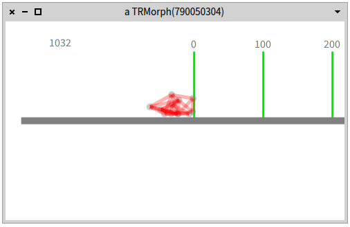

Figure 2: Adding an untrained creature to the world.

Figure 2 gives the result of the script. At that stage, the creature moves without a particular objective. The next chapter will exactly show how to make a creature evolve.

## 1.9 What have we seen in this chapter?

This chapter focuses on laying down the infrastructure to define and build zoomorphic creature. It was a very long chapter. We had to provide enough code to build up an interesting codebase on which we can experiment in the next chapter.

The chapter covers:

- a simple physical engine, supporting muscles and nodes;
- the definition of a creature and a world in which it can live.

Note that we could have added bones in the way we model creature. Once we have the notion of bone, we could have build skeletons. Although appealing, it would have significantly increased the amount of source code.